# DREAM: what trametinib switches off in A549 cells

GSE197555 — pathway and transcription factor activity with decoupleR

The differential expression report gives a list of changed genes. Here those changes are traced back to the signalling pathways (PROGENy, 14 pathways) and transcription factors (CollecTRI, ~1,200 TFs) that most likely caused them, using the footprint of known target genes rather than the expression of the pathway or TF genes themselves.

Networks were downloaded from OmniPath with decoupleR on 2026-11-09 and are stored in `analysis/resources/` so results do not drift as OmniPath is updated.

```r
library(decoupleR)
library(DESeq2)
library(org.Hs.eg.db)
library(pheatmap)
library(tidyverse)

dir.create(file.path(params$outdir, "figures"), recursive = TRUE, showWarnings = FALSE)
theme_set(theme_bw(base_size = 12))

progeny <- read_tsv(params$progeny, show_col_types = FALSE)
collectri <- read_tsv(params$collectri, show_col_types = FALSE)
```

Contrast-level input: the DESeq2 Wald statistic (trametinib vs control, corrected labels), one value per gene symbol. Sample-level input: variance-stabilised counts.

```r
de <- read_tsv(params$deseq2, show_col_types = FALSE)
stat_mat <- de |>
  filter(!is.na(symbol), !is.na(stat)) |>
  group_by(symbol) |>
  slice_max(abs(stat), n = 1, with_ties = FALSE) |>
  ungroup() |>
  (\(x) matrix(x$stat, dimnames = list(x$symbol, paste0(params$treatment, "_vs_", params$control))))()

meta <- read.csv(params$samplesheet) |>
  mutate(condition = factor(condition, levels = c(params$control, params$treatment)),
         label = paste0(condition, "_", gsm))
counts <- read_tsv(params$counts, show_col_types = FALSE) |> column_to_rownames("gene_id") |> as.matrix()
counts <- counts[rowSums(counts >= 10) >= 3, meta$sample]
colnames(counts) <- meta$label
vsd <- assay(vst(DESeqDataSetFromMatrix(counts, meta |> mutate(sample = label), ~ condition), blind = TRUE))
sym <- mapIds(org.Hs.eg.db, rownames(vsd), "SYMBOL", "ENSEMBL")
keep <- !is.na(sym) & !duplicated(sym)
expr_mat <- vsd[keep, ]
rownames(expr_mat) <- sym[keep]

tibble(genes_in_contrast = nrow(stat_mat), genes_in_sample_matrix = nrow(expr_mat))
```

```
# A tibble: 1 × 2
  genes_in_contrast genes_in_sample_matrix
              <int>                  <int>
1             15064                  15064
```

## Pathway activity (PROGENy)

Multivariate linear model: each pathway’s score accounts for the others, so shared target genes are not double counted.

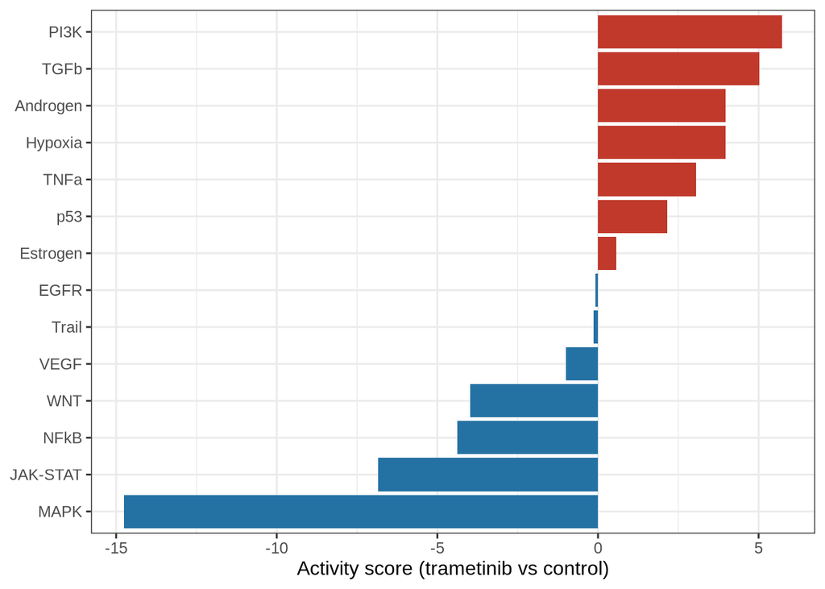

```r
pw <- run_mlm(stat_mat, progeny, .source = "source", .target = "target", .mor = "weight", minsize = 5)
write_tsv(pw, file.path(params$outdir, "progeny_contrast.tsv"))

p_pw <- pw |>
  mutate(source = fct_reorder(source, score)) |>
  ggplot(aes(score, source, fill = score > 0)) +
  geom_col() +
  scale_fill_manual(values = c(`TRUE` = "#c0392b", `FALSE` = "#2471a3"), guide = "none") +
  labs(x = paste0("Activity score (", params$treatment, " vs ", params$control, ")"), y = NULL)
ggsave(file.path(params$outdir, "figures", "progeny.png"), p_pw, width = 6, height = 4.5, dpi = 150)
p_pw
```

```r
# MEK sits directly in the MAPK pathway; if its footprint does not fall, the inputs are wrong
if (params$gate_direction != "none") {
  s <- pw$score[pw$source == params$gate_pathway]
  stopifnot(length(s) == 1, sign(s) == if (params$gate_direction == "down") -1 else 1)
}
```

**Reading:** MAPK is by far the most suppressed pathway, as expected for a MEK inhibitor. PI3K activity goes *up*: blocking MEK removes ERK’s negative feedback on upstream receptors, a well-known escape route that motivates MEK + PI3K/AKT combinations. EGFR scores near zero because its footprint overlaps MAPK, and the multivariate model assigns the shared signal to MAPK. JAK-STAT and NFkB fall alongside the interferon and inflammatory Hallmark sets seen in the enrichment report.

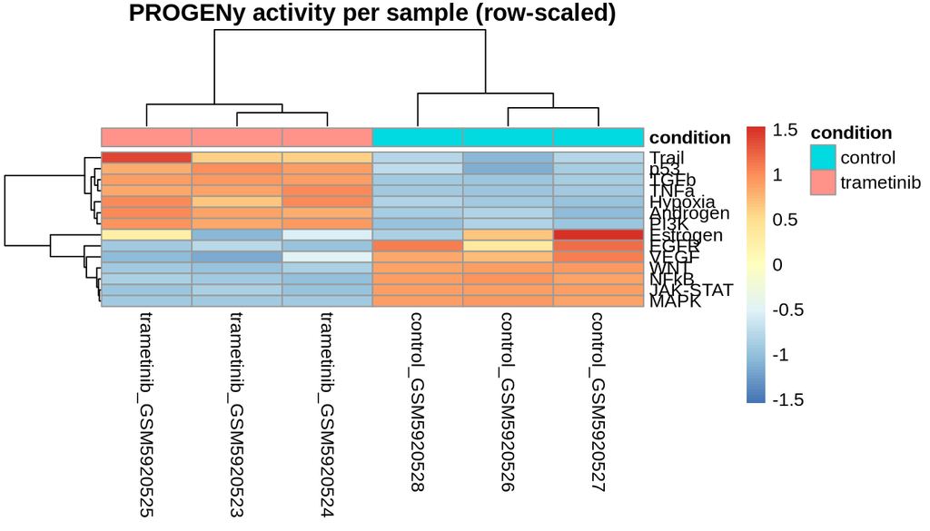

```r
pw_s <- run_mlm(expr_mat, progeny, .source = "source", .target = "target", .mor = "weight", minsize = 5)
pw_s |>
  select(source, condition, score) |>
  pivot_wider(names_from = condition, values_from = score) |>
  column_to_rownames("source") |>
  as.matrix() |>
  pheatmap(scale = "row", annotation_col = meta |> column_to_rownames("label") |> select(condition),
           main = "PROGENy activity per sample (row-scaled)")
```

## Transcription factor activity (CollecTRI)

Univariate linear model per TF; positive means the TF’s targets move in the direction the TF is known to push them.

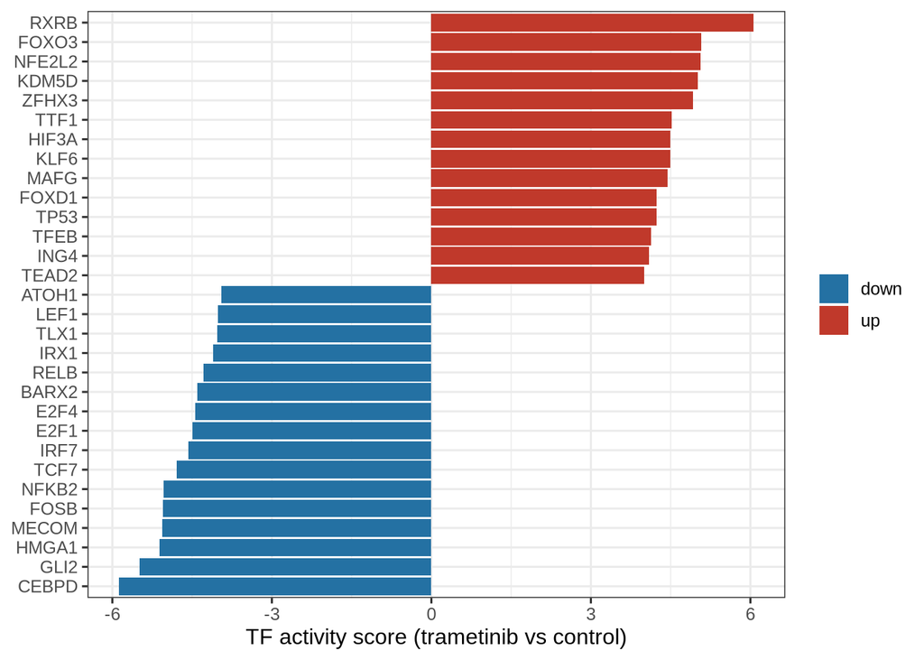

```r
tf <- run_ulm(stat_mat, collectri, .source = "source", .target = "target", .mor = "mor", minsize = 5)
write_tsv(tf |> arrange(p_value), file.path(params$outdir, "collectri_contrast.tsv"))

erk_tfs <- c("ETV1", "ETV4", "ETV5", "ELK1", "ELK4", "FOS", "FOSL1", "EGR1", "MYC", "ETS1", "ETS2")
top_tf <- tf |> filter(p_value < 0.05) |> slice_max(abs(score), n = 30)
p_tf <- top_tf |>
  mutate(source = fct_reorder(source, score),
         group = if_else(source %in% erk_tfs, "ERK-driven", if_else(score > 0, "up", "down"))) |>
  ggplot(aes(score, source, fill = group)) +
  geom_col() +
  scale_fill_manual(values = c(`ERK-driven` = "#7d3c98", up = "#c0392b", down = "#2471a3")) +
  labs(x = paste0("TF activity score (", params$treatment, " vs ", params$control, ")"), y = NULL, fill = NULL)
ggsave(file.path(params$outdir, "figures", "collectri_top30.png"), p_tf, width = 6.5, height = 7, dpi = 150)
p_tf
```

Known ERK-driven transcription factors:

```r
tf |> filter(source %in% erk_tfs) |> select(source, score, p_value) |> arrange(score) |>
  knitr::kable(digits = 3)
```

| source | score | p_value |
| --- | --- | --- |
| MYC | -2.484 | 0.013 |
| FOSL1 | -2.224 | 0.026 |
| ETS1 | -2.163 | 0.031 |
| ETV4 | -1.519 | 0.129 |
| EGR1 | -1.476 | 0.140 |
| ELK4 | -1.399 | 0.162 |
| ETV5 | -1.242 | 0.214 |
| FOS | -0.200 | 0.842 |
| ETS2 | 0.035 | 0.972 |
| ETV1 | 0.455 | 0.649 |
| ELK1 | 0.792 | 0.428 |

**Reading:** MYC, FOSL1 and ETS1, all stabilised or induced by ERK, lose activity. ETV4/ETV5 point the same way but have few curated targets in CollecTRI, so their footprint is weak even though the genes themselves fall 30-200x. FOXO3 gains activity, consistent with ERK normally phosphorylating FOXO3 for degradation, and NFE2L2 (NRF2) gains activity, matching the oxidative stress signal in the Hallmark results.

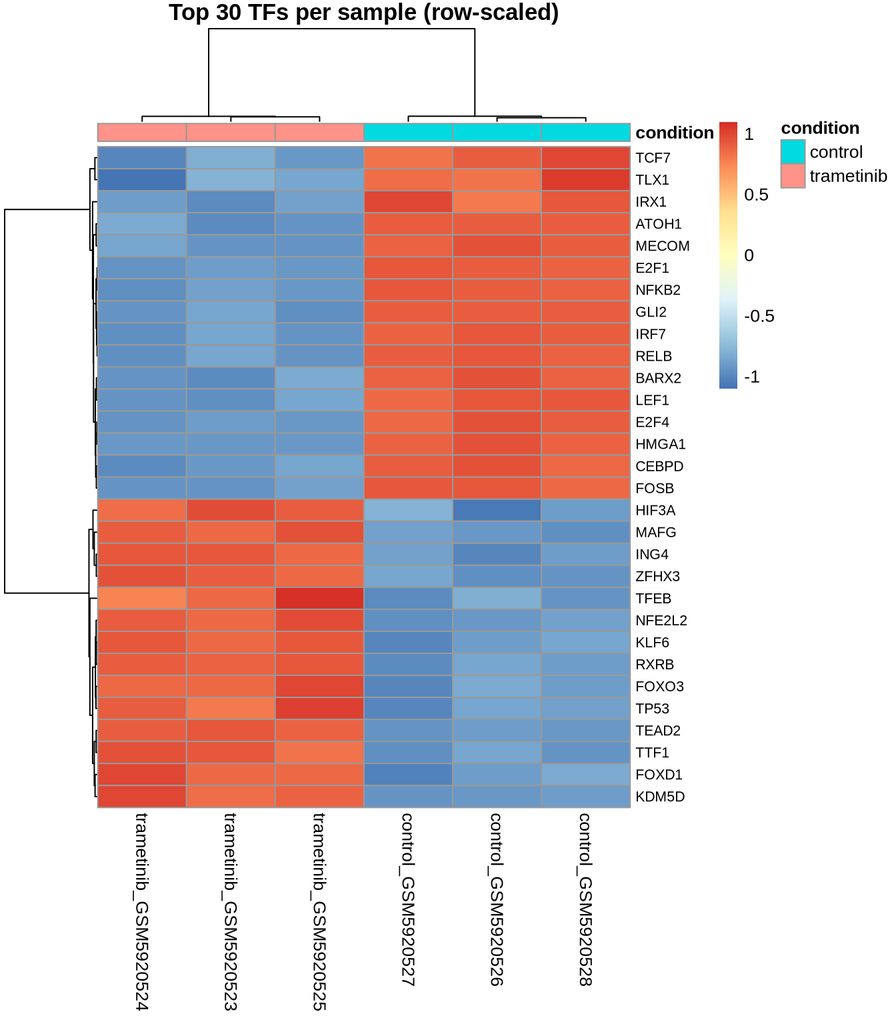

```r
tf_s <- run_ulm(expr_mat, collectri, .source = "source", .target = "target", .mor = "mor", minsize = 5)
tf_s |>
  filter(source %in% top_tf$source) |>
  select(source, condition, score) |>
  pivot_wider(names_from = condition, values_from = score) |>
  column_to_rownames("source") |>
  as.matrix() |>
  pheatmap(scale = "row", annotation_col = meta |> column_to_rownames("label") |> select(condition),
           fontsize_row = 8, main = "Top 30 TFs per sample (row-scaled)")
```